# ECON 490 - Applied Machine Learning in Economics Problem Set 2 (100pts) - due date: Thursday, February 24

Adam Wawrowski (adamw4)

2/24/2022

# Answer 1

$$\begin{aligned}
H_0:\:\beta_{TV}=\beta_{radio}=\beta_{newspaper}=0
\end{aligned}$$

$$\\[.005in]$$

In context of the data, the p-values correspond to the null hypothesis that the variables of money spent on TV, radio, and newspaper advertisements have no effect on sales.

$$\\[.005in]$$

The p-value for the variable **TV ad expenditure** is very small, less than 0.0001. As such, we can reject the null hypothesis, concluding that money spent on TV advertisements have an effect on sales.

The p-value for the variable **radio ad expenditure** is very small, less than 0.0001. As such, we can reject the null hypothesis, concluding that money spent on radio advertisements have an effect on sales.

The p-value for the variable **newspaper ad expenditure** is very large, greater than 0.01, 0.05, and 0.1. As such, we fail to reject the null hypothesis, concluding that the money spent on newspaper advertisements do not have an effect on sales.

# Answer 2

1. For a fixed value of IQ and GPA, high school graduates earn more, on average, than college graduates provided that the GPA is high enough. Let’s observe the regression model under the conditions of a high school graduate and college graduate.

$$\\[.005in]$$

$$\begin{array}
\\\hat{Salary}_{High School}=50+20X_1+0.07X_2+0.01X_4
\\\hat{Salary}_{College}=85+10X_1+0.07X_2+0.01X_4
\\\hat{Salary}_{High School}-\hat{Salary}_{College}=10X_1-35
\end{array}$$

$$\\[.005in]$$

High school graduates will earn more, on average, than college graduates if this difference is positive. As such,

$$\\[.005in]$$

$$\begin{aligned}
0<10X_1-35 \iff X_1>3.5
\end{aligned}$$

$$\\[.005in]$$

After taking the difference, high school graduates will earn more, on average, than college graduates if their GPA is higher than 3.5

2. Substitute the inputs into the equation.

```r
50 + 20*(4) + 0.07*(110) + 35*(1) + 0.01*(110)*(4) - 10*(4)*(1)
```

```
## [1] 137.1
```

The salary of a college graduate with IQ of 110 and a GPA of 4.0 is 137.1 thousand.

3. False, the value of the coefficient is not a measure of the significance of a term. The significance of a term is measured by a F-test or t-test in general cases.

# Answer 3

```r
set.seed(1)
x <- rnorm(100, 0, 1)
head(x)
```

```
## [1] -0.6264538  0.1836433 -0.8356286  1.5952808  0.3295078 -0.8204684
```

```r
eps <- rnorm(100, 0, 0.25)
head(eps)
```

```
## [1] -0.15509167  0.01052897 -0.22773041  0.03950719 -0.16364616  0.44182182
```

```r
y = -1 + 0.5*x + eps
length(y)
```

```
## [1] 100
```

The length of y is 100. The value of β0 is -1 and β1 is 0.5.

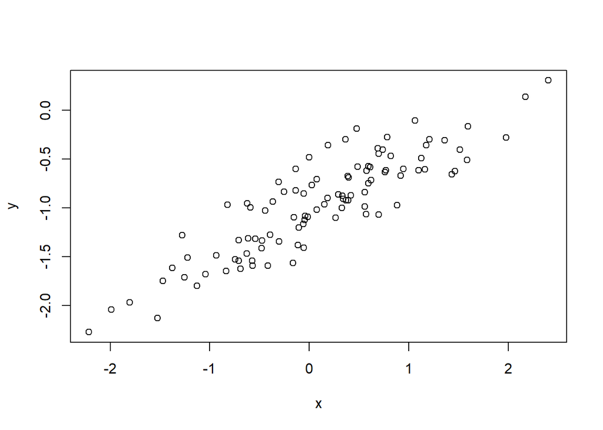

```r
plot(x,y)
```

The plot exhibits a positive linear trend.

```r
model <- lm(y ~ x)
summary(model)
```

```
##
## Call:
## lm(formula = y ~ x)
##
## Residuals:
##      Min       1Q   Median       3Q      Max
## -0.46921 -0.15344 -0.03487  0.13485  0.58654
##
## Coefficients:
##             Estimate Std. Error t value Pr(>|t|)
## (Intercept) -1.00942    0.02425  -41.63   <2e-16 ***
## x            0.49973    0.02693   18.56   <2e-16 ***
## ---
## Signif. codes:  0 '***' 0.001 '**' 0.01 '*' 0.05 '.' 0.1 ' ' 1
##
## Residual standard error: 0.2407 on 98 degrees of freedom
## Multiple R-squared:  0.7784, Adjusted R-squared:  0.7762
## F-statistic: 344.3 on 1 and 98 DF,  p-value: < 2.2e-16
```

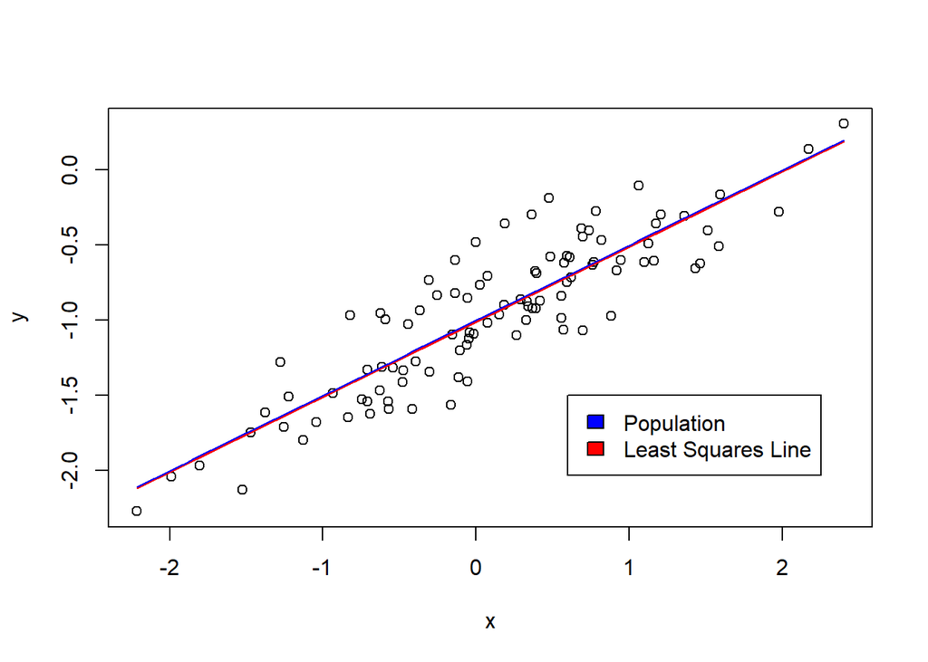

```r
plot(x,y)
lines(x, model$fitted.values, col="red")
curve(-1 + 0.5*x, add = TRUE, col="blue")
legend(0.6, -1.5, legend=c("Population", "Least Squares Line"), c("blue","red"))
```

```r
modelPoly <- lm(y ~ x + I(x^2))
summary(modelPoly)
```

```
##
## Call:
## lm(formula = y ~ x + I(x^2))
##
## Residuals:
##     Min      1Q  Median      3Q     Max
## -0.4913 -0.1563 -0.0322  0.1451  0.5675
##
## Coefficients:
##             Estimate Std. Error t value Pr(>|t|)
## (Intercept) -0.98582    0.02941 -33.516   <2e-16 ***
## x            0.50429    0.02700  18.680   <2e-16 ***
## I(x^2)      -0.02973    0.02119  -1.403    0.164
## ---
## Signif. codes:  0 '***' 0.001 '**' 0.01 '*' 0.05 '.' 0.1 ' ' 1
##
## Residual standard error: 0.2395 on 97 degrees of freedom
## Multiple R-squared:  0.7828, Adjusted R-squared:  0.7784
## F-statistic: 174.8 on 2 and 97 DF,  p-value: < 2.2e-16
```

# Answer 4

```r
library(ISLR2)
attach(Carseats)
```

```r
head(Carseats)
```

```
##   Sales CompPrice Income Advertising Population Price ShelveLoc Age Education
## 1  9.50       138     73          11        276   120       Bad  42        17
## 2 11.22       111     48          16        260    83      Good  65        10
## 3 10.06       113     35          10        269    80    Medium  59        12
## 4  7.40       117    100           4        466    97    Medium  55        14
## 5  4.15       141     64           3        340   128       Bad  38        13
## 6 10.81       124    113          13        501    72       Bad  78        16
##   Urban  US
## 1   Yes Yes
## 2   Yes Yes
## 3   Yes Yes
## 4   Yes Yes
## 5   Yes  No
## 6    No Yes
```

```r
modelCar <- lm(Sales ~ US + ShelveLoc + Price + CompPrice + Price * CompPrice)
summary(modelCar)
```

```
##
## Call:
## lm(formula = Sales ~ US + ShelveLoc + Price + CompPrice + Price *
##     CompPrice)
##
## Residuals:
##     Min      1Q  Median      3Q     Max
## -3.7246 -0.9981 -0.0298  1.0370  3.9839
##
## Coefficients:
##                   Estimate Std. Error t value Pr(>|t|)
## (Intercept)      5.9476224  2.3093485   2.575   0.0104 *
## USYes            1.0701778  0.1552945   6.891 2.21e-11 ***
## ShelveLocGood    4.7900970  0.2202411  21.749  < 2e-16 ***
## ShelveLocMedium  1.8389298  0.1808034  10.171  < 2e-16 ***
## Price           -0.1082077  0.0200777  -5.389 1.22e-07 ***
## CompPrice        0.0756914  0.0192210   3.938 9.72e-05 ***
## Price:CompPrice  0.0001297  0.0001593   0.814   0.4161
## ---
## Signif. codes:  0 '***' 0.001 '**' 0.01 '*' 0.05 '.' 0.1 ' ' 1
##
## Residual standard error: 1.475 on 393 degrees of freedom
## Multiple R-squared:  0.7313, Adjusted R-squared:  0.7272
## F-statistic: 178.3 on 6 and 393 DF,  p-value: < 2.2e-16
```

3. **Sales** = 5.9476224 + 1.0701778 * **(USYes)** + 4.7900970 * **(ShelveLocGood)** + 1.8389298 * **(ShelveLocMedium)** - 0.1082077 * **(Price)** + 0.0756914 **(CompPrice)** + 0.0001297 * **(Price)** * **(CompPrice)**
4. **USYes**: If the store is located in the US, then there is an estimated increase of 1.0701778 in sales.

**ShelveLocGood**: If the shelving location for the car seats is good, then there is an estimated increase of 4.7900970 in sales.

**ShelveLocMedium**: If the shelving location for the car seats is medium, then there is an estimated increase of 1.8389298 in sales.

**Price**: For every $1 increase of price, there is an estimated decrease of 0.1082077 in sales.

**CompPrice**: For every $1 increase of price charged by competitor, there is an estimated increase of 0.0756914 in sales.

**Price * CompPrice**: For every $1 increase in the interaction between price charged and price charged by competitor, there is an estimated increase of 0.0001297 in sales.

5. We can reject the null hypothesis for the predictors UsYes, ShelveLocGood, ShelveLocMedium, Price, and CompPrice.

```r
modelCarS <- lm(Sales ~ US + ShelveLoc + Price + CompPrice)
summary(modelCarS)
```

```
##
## Call:
## lm(formula = Sales ~ US + ShelveLoc + Price + CompPrice)
##
## Residuals:
##     Min      1Q  Median      3Q     Max
## -3.7103 -1.0142 -0.0419  1.0505  3.9650
##
## Coefficients:
##                  Estimate Std. Error t value Pr(>|t|)
## (Intercept)      4.137305   0.622690   6.644 1.02e-10 ***
## USYes            1.061503   0.154862   6.855 2.77e-11 ***
## ShelveLocGood    4.789889   0.220147  21.758  < 2e-16 ***
## ShelveLocMedium  1.843933   0.180622  10.209  < 2e-16 ***
## Price           -0.092167   0.003852 -23.924  < 2e-16 ***
## CompPrice        0.090573   0.005937  15.257  < 2e-16 ***
## ---
## Signif. codes:  0 '***' 0.001 '**' 0.01 '*' 0.05 '.' 0.1 ' ' 1
##
## Residual standard error: 1.474 on 394 degrees of freedom
## Multiple R-squared:  0.7308, Adjusted R-squared:  0.7274
## F-statistic:   214 on 5 and 394 DF,  p-value: < 2.2e-16
```

7. In terms of R^2, both models hover around 0.73. In context, the variables in the two models explain 73% of the variability in the sales of car seats. Also, the two models carry a RSE of about 1.475. Meaning, the regression models predict the sales of car seats with an average error of 1.475. The models in (b) and (f) fit the data very accurately, but not perfectly.

```r
confint(modelCarS)
```

```
##                       2.5 %      97.5 %
## (Intercept)      2.91309549  5.36151487
## USYes            0.75704378  1.36596273
## ShelveLocGood    4.35707958  5.22269766
## ShelveLocMedium  1.48883096  2.19903600
## Price           -0.09974071 -0.08459269
## CompPrice        0.07890187  0.10224457
```

# Answer 5

```r
exp(-6 + 0.05*40 + 3.5)/(1+exp(-6 + 0.05*40 + 3.5))
```

```
## [1] 0.3775407
```

The probability that a student that studies for 40 hours and has an undergrad GPA of 3.5 gets an A in the class is 0.3775407.

2. We have to solve for the number of hours required to have a 50% chance of getting an A in the class.

$$\\[.005in]$$

$$\begin{aligned}
0.5 =\frac{e^{-6+0.05x+3.5}}{1+e^{-6+0.05x+3.5}} \iff x=50
\end{aligned}$$

$$\\[.005in]$$

To check, input into regression.

```r
exp(-6 + 0.05*50 + 3.5)/(1+exp(-6 + 0.05*50 + 3.5))
```

```
## [1] 0.5
```

The student in part (a) would need to study 50 hours to have a 50% chance of getting an A in the class.

# Answer 6

1. $$\begin{aligned}
   Odds\:of\:Defaulting=0.37=\frac{x}{1-x} \iff x=\frac{37}{137}=0.270073...
   \end{aligned}$$

$$\\[.005in]$$

The fraction of people with an odds of 0.37 of defaulting on their credit card payment is 0.270073.

2. $$\begin{aligned}
   Odds\:of\:Defaulting=x=\frac{0.16}{1-0.16} \iff x=\frac{4}{21}=0.19048...
   \end{aligned}$$

$$\\[.005in]$$

The odds that an individual will default on her credit card payment is 0.19048.